# About the Data:-

The dataset includes:

WuzzufJobPosts_Sample : a sample of jobs posted on WUZZUF during 2014-2016.

WuzzufApplicationsSample : the corresponding applications (Excluding some entries).

Note: The jobs are mainly in Egypt but other locations are included.

Note: This Exploration is only about WuzzufJobPosts_Sample dataset

# 1) univariate

### What is the most popular job industries?

###### it's obvious that computer science, IT services, and computer-related industries are the most popular industries on WUZZUF

###### then we have marketing , engineering & education

###### then business-related industries

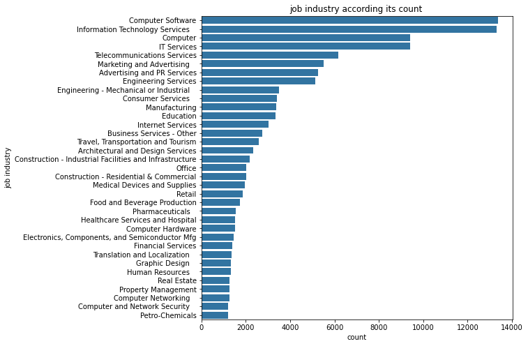

### What is the most popular job categories ?

###### software-related categories are the most popular

###### then business-related

###### then engineering

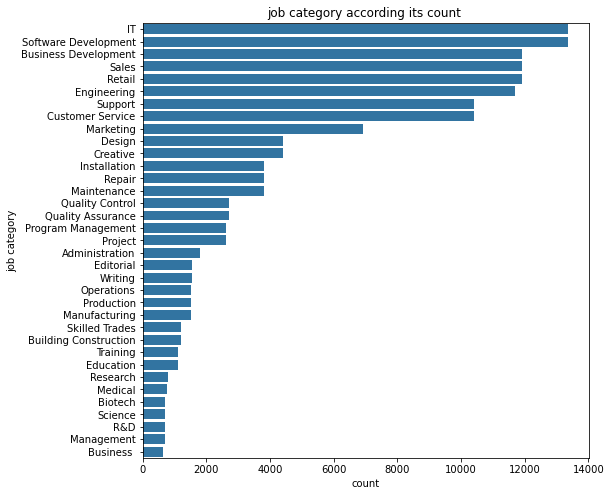

### What is the most active cities in posting jobs?

###### You can see that Cairo, Giza & Alexandria are more active in posing jobs than the others

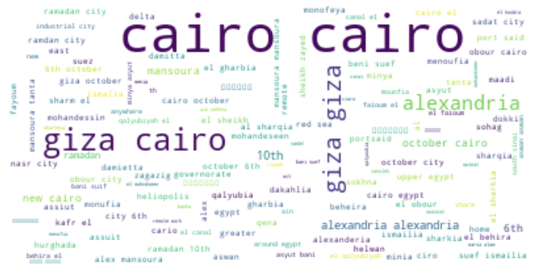

### What is the top job titles ?

###### Call center , sales engineer, customer servies, graphing designer and social media

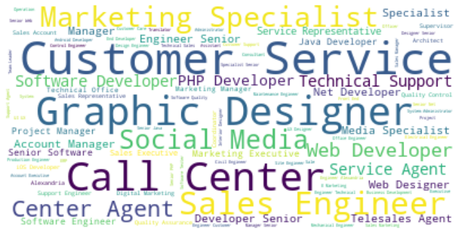

### Describe Minimum & Maximum salary in Egyptian Pound

###### - in minimum salaries the majority From 1000 LE to 3500 LE vs from 2000 LE to 6000 LE in maximum salaries

###### - in minimum salaries, from 3500 LE to 8000 LE is common knowing it's reducing starting from 3500 LE , after 8000 LE is rare

###### -in maximum salaries, from 6000 LE to 8000 LE is common also 10000 , knowing it's reducing starting from 6000 , after 10000 is rare

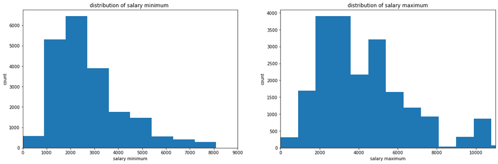

### what is the chance for a fresh grad to get a job ?

###### actually, there are huge amount of opportunities for the fresh grad to get a job as the figure shows

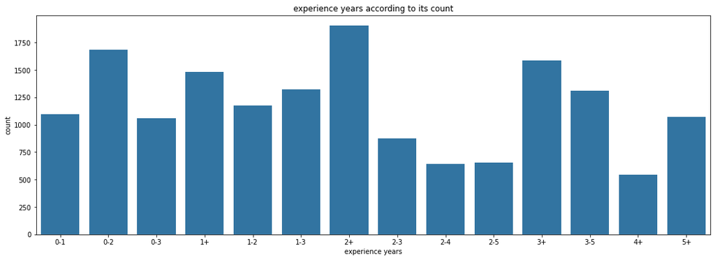

# 2) Bivariate

### What are the most profitable jobs?

###### - sports jobs have the highest minimum salary then manegment then business-related

###### - training jobs have the highest maximum salary then education-related then business-related

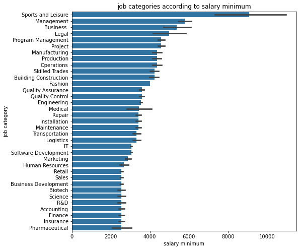

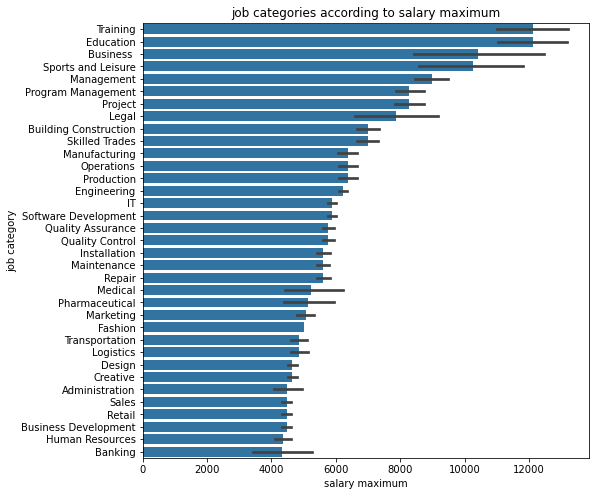

### Describe the difference in salaries for different career levels

###### salaries are increasing exponentially

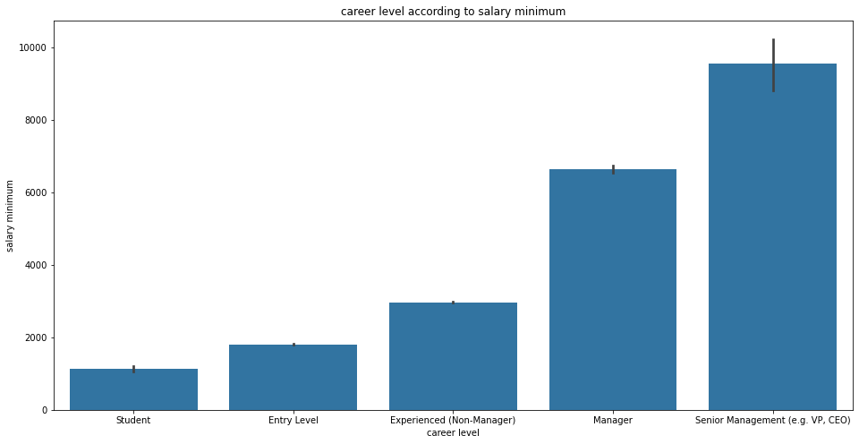

### What are the most profitable job industries?

###### security and surveillance industry has the highest minimum salary then waste management the plastic

###### plastic has the highest maximum salary then security and surveillance then business supplies and equipment

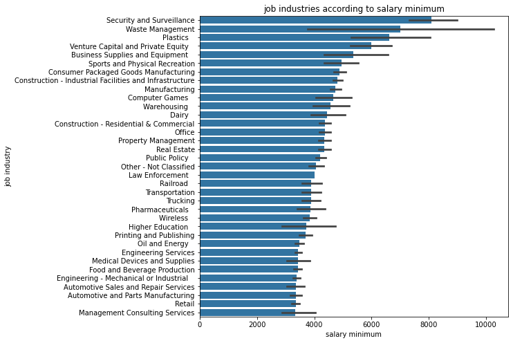

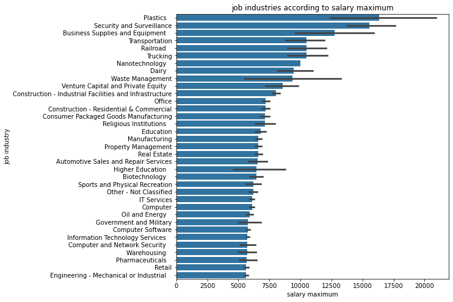

### If I'm a company that wants to post a job, which month can I post?

###### I recommend posting in September but if you have to post it quickly just don't post it on may

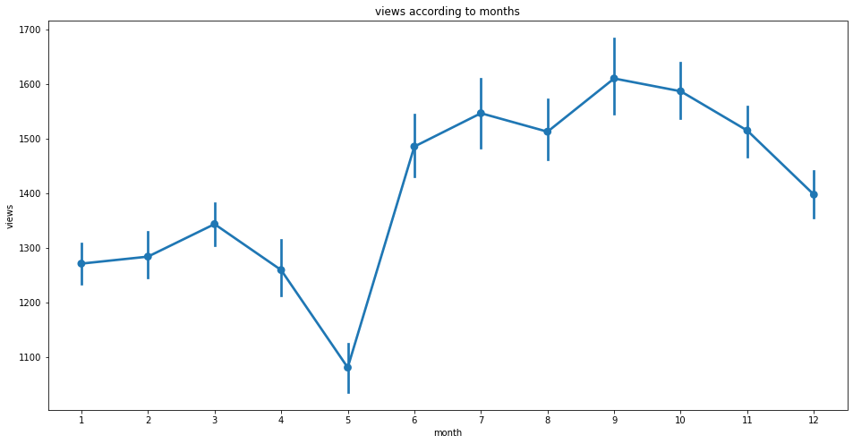